# textsum

Neural Text Generation

## Introduction

We will be focusing on neural conditional text generation, or natural language generation (NLG). In the simplest form, the task can be formulated as $$ y ← g(x) $$ where $x$ is the input text sequence, $y$ is the output text sequence, $g$ is the neural text generation model. For example, $x$ can be an English sentence, $y$ can be a Chinese sentence, and then $g$ is a machine translation model. Similarly, $x$ can be a long news article, $y$ can be a short summary, and then $g$ is text summarization model. We will use text summarization as our target task.

## 1. Huggingface Transformers and Datasets

We will use the libraries provided by [Huggingface](https://huggingface.co/), including the famous [Transformers](https://huggingface.co/docs/transformers/index) library and the [Datasets](https://huggingface.co/docs/datasets/index) library. Let's first install them.

```python
%pip install transformers
%pip install datasets
import transformers
import datasets
```

Let's import the other packages. Please check again to make sure you have the GPU access.

```python
import torch
import torch.nn as nn
import torch.nn.functional as F
import torch.optim as optim
from torch import Tensor

from typing import Tuple, List

import random
import math
import os
import time
import json
import numpy as np
from collections import Counter

# We'll set the random seeds for deterministic results.
SEED = 1

random.seed(SEED)
torch.manual_seed(SEED)
torch.backends.cudnn.enabled = False
torch.backends.cudnn.deterministic = True

class Placeholder:
    @property
    def DO(self):
        raise NotImplementedError("You haven't yet implemented this part of the assignment yet")

TO = Placeholder()


DEVICE = torch.device("cuda" if torch.cuda.is_available() else "cpu")
print("Pytorch version is: ", torch.__version__)
print("You are using: ", DEVICE)
```

```
Pytorch version is:  2.2.1+cu121
You are using:  cuda
```

### XSum on Huggingface Datasets

The dataset we are going to use is [XSum](https://aclanthology.org/D18-1206.pdf), which is one of the most commonly used datasets for abstractive text summarization.

We will use the Huggingface Datasets library to get our dataset. Check out their [documentation](https://huggingface.co/docs/datasets/quickstart) for more information.

Below we load XSum using HF Datasets.

We will only use the first 100 examples in the test set of XSum for the following parts to save the computation time. The entire test set in fact contains more than 10k examples and the training set contains more than 200k examples.

https://huggingface.co/datasets/xsum

```python
# get the first 100 data examples in the test split
dataset = datasets.load_dataset("xsum", split="test[:100]")
# check the dataset information
print(dataset.info.features)
```

### BART on Huggingface Transformers

The model we are going to use is [BART](https://aclanthology.org/2020.acl-main.703.pdf) (Bidirectional and Auto-Regressive Transformers).

The specific BART checkpoint we are going to use is first *pre-trained* on large corpora and *fine-tuned* on XSum already.

We are going to use HF Transformers to load this fine-tuned BART checkpoint. HF Transformers hosts more than 10k of different model [checkpoints](https://huggingface.co/models), and make them easily accessible through the library.

As you will see below, first we import [BART](https://huggingface.co/docs/transformers/model_doc/bart) from Transformers, and then load the model parameters with a specific model checkpoint [`facebook/bart-large-xsum`](https://huggingface.co/facebook/bart-large-xsum).

```python
from transformers import BartForConditionalGeneration, BartTokenizer
model_name = "facebook/bart-large-xsum"
tokenizer = BartTokenizer.from_pretrained(model_name)  # load the tokenizer
model = BartForConditionalGeneration.from_pretrained(model_name).to(DEVICE)  # load the model
```

### Dataloader

Before we going to the next sections, let's define a dataloader that transforms the data examples into batches of model input.

```python
def dataloader(batch_size):
    for i in range(0, len(dataset), batch_size):
        batch = dataset[i:i+batch_size]
        articles = tokenizer(
                batch["document"],
                return_tensors="pt",
                padding="longest",
                add_special_tokens=True,
                truncation=True,
                max_length=512,
            ).to(DEVICE)
        input_ids = articles["input_ids"]
        attention_mask = articles["attention_mask"]
        summaries = tokenizer(
                batch["summary"],
                return_tensors="pt",
                padding="longest",
                add_special_tokens=True,
                truncation=True,
                max_length=128,
            ).to(DEVICE)
        target_input_ids = summaries["input_ids"]
        target_attention_mask = summaries["attention_mask"]
        yield {
            "input_ids": input_ids,
            "attention_mask": attention_mask,
            "target_input_ids": target_input_ids,
            "target_attention_mask": target_attention_mask,
            "articles": batch["document"],
            "summaries": batch["summary"],
        }
```

## 2. Training Text Summarization Models

In this section we are going to look into the training process of text summarization models. The standard training algorithm for text summarization model is Maximum Likelihood Estimation (MLE), and the loss function for this training algorithm is the cross-entropy loss: $$ L_{xent} = - \sum_{i=1}^l \log p_{model}(\tilde{w}_i|\tilde{w}_{0, ..., i-1}, D), $$ where $D$ is the input document, $\tilde{w}$ is the *reference* summary with length $l+1$ including $\tilde{w}_0$ always set to a special token **BOS** (begin-of-sequence), and $\tilde{w}_i$ is the $i$-th token. Note that this training algorithm is also called *teacher-forcing*, since the model is required to predict the $i$-th token of the reference summary given the prefix of the reference summary before the $i$-th token.

To train the summarization model, we will take a batch of data examples and compute the loss in the *forward step*, and take the gradient of the model parameters w.r.t. the loss function in the *backward step*, then use an optimization algorithm (e.g., gradient descent) to update the model parameters. Usually such a training process can take a long time. Due to the computation resource limitations, we will only implement the forward step below. In the next block, we are going to implement a function `compute_loss`, which computes the cross-entropy loss given a batch of input data points and a summarization model and returns the computed loss.

```python
def compute_loss(model, batch):
    """
    Args:
        model: the summarization model
        batch: a batch of data from the dataloader

    Return:
        loss: the computed average loss
    """

    # calculate cross entropy
    labels =  batch['target_input_ids'][:, 1:] # Shift the labels by one to align with predicted probabilities
    outputs = model(batch['input_ids'],
                    attention_mask=batch['attention_mask'],
        decoder_input_ids=batch['target_input_ids'][:, :-1],  # Remove last token from decoder input
        decoder_attention_mask=batch['target_attention_mask'][:, :-1]  # Remove last token from decoder attention mask
    )

    logits = outputs.get("logits") # Get the logits from the model outputs

    # Ignore PAD token in computation
    non_pad_indices = labels != tokenizer.pad_token_id

    log = logits[non_pad_indices]
    l = labels[non_pad_indices]

    # Compute cross-entropy loss manually
    y_onehot = torch.zeros(l.size(0), log.shape[-1]).to(DEVICE) # Initialize loss
    y_onehot.scatter_(1, l.view(-1, 1).long(), 1).float()
    z = (torch.exp(log.t()) / torch.sum(torch.exp(log), dim=1)).t()

    # Negative log likelihood
    loss_scratch = torch.mean(-torch.sum(torch.log(z) * (y_onehot), dim=1)).to(DEVICE)

    return loss_scratch
```

Let's test it! The loss should be exactly 1.6260 (although a little rounding error is allowed.)

```python
batches = dataloader(batch_size=8)
batch = next(batches) # get one batch of data
model = model.eval()
with torch.no_grad():
  loss = compute_loss(model, batch)
print(loss)
```

```
tensor(1.6260, device='cuda:0')
```

## 3. Text Summarization Evaluation

In this section we will focus on the **evaluation** of text summarization models.

Having trained a summarization model, an important question is **how good the model is?** To answer this question, we will need to perform the following steps:

1. Using the summarization model to generate the *candidate summaries* on the *test set*. This procedure is also called as **inference**. For an autoregressive NLG model as BART, at one inference step $t$ it predicts the probabiltiy distribution of the next token based on its *own* previously predicted tokens $\hat{w}_{0, ..., t-1}$ and the input document $D$: $$ p_t(w_i) = p_{model}(w_i|\hat{w}_{0, ..., t-1}, D), $$ where $w_i$ stands for a possible token in the vocabulary. The actual token as time stamp $t$ depends on the specific **decoding algorithm**. For example, if *greedy decoding* is used, then we select the most probable token according to $p_t$: $$ \hat{w_t} = \arg \max_{w_i} p_t(w_i). $$ Later we will explore other decoding algorithms that can yield better results.
2. Having obtained the candidate (system-generated) summaries on the test set, we evalaute the quality of the candidate summaries against the reference summaries provided in the dataset. This can be achieved by either *human evaluation* or *automatic evaluation* with **automatic evaluation metrics**. The evaluation result for one summarization model is usually a numerical score, which can be the quality score of its generated summaries over the test set. Then, we can compare the performance of different summarization models by comparing their evaluation scores.

### ROUGE for Automatic Summarization Evaluation

In this part, we are going to implement [ROUGE](https://aclanthology.org/W04-1013.pdf), the most important and commonly used automatic evaluation metric for text summarization.

While there are more than 100 [variants](https://aclanthology.org/D15-1013.pdf) of ROUGE, we are going to use its most basic settings: ROUGE-N, which is based on n-grams matching between the reference and candidate summaries. Concretely, the ROUGE-N recall score is as follows: $$ \textrm{ROUGE-N}_{R} =\sum_{m \in \mathcal{M}_n} \frac{\mathrm{Count}_{\mathrm{Match}}(m)}{\mathrm{Count}(m)}, $$ where $\mathcal{M}_n$ is the set of unique $n$-grams in the reference summary, $\mathrm{Count}(m)$ is the number of occurrence of n-gram $m$ in the reference summary, $\mathrm{Count}_{\mathrm{Match}}(m)$ is the number of co-occurrence of n-gram $m$ in both the reference summary and candidate summary.

The ROUGE precision score can be defined by replacing the role of reference and candidate summary. Then we can compute the ROUGE [F1](https://en.wikipedia.org/wiki/F-score) score. Please note that ROUGE score is defined at the summary level, and the model performance can be evaluated by averaging over the ROUGE score of its generated summaries over the entire test set.

We will implement a function `rouge` in the next code block, which takes three input arguments, `hypothesis`, `reference`, `ngram`, standing for the candidate summary, reference summary, $n$ in the $n$-gram, respectively.

The output will be a dictionary with three attributes: `recall`, `precision`, `f1` for the computed ROUGE recall, precision and f1 score.

```python
import collections

def rouge(hypothesis, reference, ngram):
    """
    Compute ROUGE scores for a given hypothesis and reference summary.

    Args:
        hypothesis: A list of tokens representing the candidate summary.
        reference: A list of tokens representing the reference summary.
        ngram: The size of the n-grams for ROUGE calculation.

    Returns:
        A dictionary containing ROUGE recall, precision, and F1 score.
    """
    # Generate n-grams for hypothesis and reference
    hypothesis_ngrams = generate_ngrams(hypothesis, ngram)
    reference_ngrams = generate_ngrams(reference, ngram)

    # Compute overlap between n-grams
    overlap_count = sum((collections.Counter(hypothesis_ngrams) & collections.Counter(reference_ngrams)).values())

    # Compute ROUGE recall, precision, and F1 score
    recall = overlap_count / max(len(reference_ngrams), 1)
    precision = overlap_count / max(len(hypothesis_ngrams), 1)
    f1 = (2 * precision * recall) / max((precision + recall), 1e-5)  # Avoid division by zero

    return {'recall': recall, 'precision': precision, 'f1': f1}

def generate_ngrams(tokens, n):
    """
    Generate n-grams from a list of tokens.

    Args:
        tokens: A list of tokens.
        n: The size of the n-grams.

    Returns:
        A list of n-grams.
    """
    ngrams = []
    for i in range(len(tokens) - n + 1):
        ngram = ' '.join(tokens[i:i+n])
        ngrams.append(ngram)
    return ngrams
```

Having implemented ROUGE, we will use it to evaluate the performance of the pre-trained BART on XSum. To do that, we first let the model generate the candidate summaries (the **inference** step).

```python
batches = dataloader(batch_size=8)  # get batches

model = model.eval()
candidates = []
references = []
with torch.no_grad():
    for (i, batch) in enumerate(batches):
        print(f"batch {i+1}")
        summary_ids = model.generate(batch["input_ids"], num_beams=6, max_length=62)  # inference
        summaries = tokenizer.batch_decode(summary_ids, skip_special_tokens=True)  # decoding
        candidates.extend(summaries)
        references.extend(batch["summaries"])
```

```
batch 1
batch 2
batch 3
batch 4
batch 5
batch 6
batch 7
batch 8
batch 9
batch 10
batch 11
batch 12
batch 13
```

Finally, we use ROUGE to evaluate the quality of the candidate summaries. We provide a tokenization function that tokenizes the summaries as a pre-processing before ROUGE.

```python
import re
import six

# Pre-compile regexes that are use often
NON_ALPHANUM_PATTERN = r"[^a-z0-9]+"
NON_ALPHANUM_RE = re.compile(NON_ALPHANUM_PATTERN)
SPACES_PATTERN = r"\s+"
SPACES_RE = re.compile(SPACES_PATTERN)
VALID_TOKEN_PATTERN = r"^[a-z0-9]+$"
VALID_TOKEN_RE = re.compile(VALID_TOKEN_PATTERN)


def tokenize(text):
    """Tokenize input text into a list of tokens.
    This approach aims to replicate the approach taken by Chin-Yew Lin in
    the original ROUGE implementation.
    Args:
    text: A text blob to tokenize.
    Returns:
    A list of string tokens extracted from input text.
    """

    # Convert everything to lowercase.
    text = text.lower()
    # Replace any non-alpha-numeric characters with spaces.
    text = NON_ALPHANUM_RE.sub(" ", six.ensure_str(text))

    tokens = SPACES_RE.split(text)

    # One final check to drop any empty or invalid tokens.
    tokens = [x for x in tokens if VALID_TOKEN_RE.match(x)]

    return tokens

for n in range(1, 4):
    f1, prec, recall, cnt = 0, 0, 0, 0
    for (x, y) in zip(candidates, references):
        x = tokenize(x)
        y = tokenize(y)
        score = rouge(x, y, n)
        f1 += score["f1"]
        prec += score["precision"]
        recall += score["recall"]
        cnt += 1
    print(f"ROUGE-{n} F1: {f1:.3f}, Precision: {prec:.3f}, Recall: {recall:.3f}")
```

```
ROUGE-1 F1: 44.037, Precision: 46.477, Recall: 43.166
ROUGE-2 F1: 21.686, Precision: 22.964, Recall: 21.246
ROUGE-3 F1: 12.582, Precision: 13.353, Recall: 12.338
```

## 4. Decoding Algorithms

Recall from the previous section that the first step we are going to perform when evalauting NLG models is to use the summarization model to generate the *candidate summaries* on the *test set*. This procedure is also called as **inference**.

For an autoregressive NLG model as BART, at one inference step $t$ it predicts the probabiltiy distribution of the next token based on its *own* previously predicted tokens $\hat{w}_{0, ..., t-1}$ and the input document $D$: $$ p_t(w_i) = p_{model}(w_i|\hat{w}_{0, ..., t-1}, D), $$ where $w_i$ stands for a possible token in the vocabulary. The actual token as time stamp $t$ depends on the specific **decoding algorithm**.

In this section, you are going to implement several different decoding algorithms:

1. Greedy Decoding
2. Sampling
3. Beam Search

**Note:** While most of the Huggingface NLG models have a `.generate()` function supporting different decoding algorithms, we are going to implement the algorithms without using this function.

One thing to keep in mind is *when* should the generation stop. In our case, it stops when either a pre-defined condition is reached (e.g. a maximum generation length), or a special **end-of-sequence (EOS)** token is predicted as the next token. We can get the index of this token via `tokenizer.eos_token_id`. We can also access the BOS token and PAD token in similar manners.

**Note**: in the following sections, we always assume the generated summary starts with a BOS token and ends with a EOS token, and the summary length is counted with both of them.

Before we go to the next sections, let's first define an evaluation function using ROUGE. We will use a reference ROUGE implementation instead for consistent results.

```python
%pip install rouge_score
```

```python
from rouge_score import rouge_scorer

scorer = rouge_scorer.RougeScorer(['rouge1', 'rouge2', 'rouge3'],
                                  use_stemmer=False, split_summaries=False)

def evaluate_rouge(candidates, references):
    scores = [scorer.score(x, y) for x, y in zip(references, candidates)]
    for n in range(1, 4):
        f1, prec, recall, cnt = 0, 0, 0, 0
        for score in scores:
            f1 += score[f"rouge{n}"].fmeasure
            prec += score[f"rouge{n}"].precision
            recall += score[f"rouge{n}"].recall
            cnt += 1
        print(f"ROUGE-{n} F1: {f1:.3f}, Precision: {prec:.3f}, Recall: {recall:.3f}")
```

### Greedy Decoding

When greedy decoding is used, we select the most probable token according to $p_t$: $$ \hat{w_t} = \arg \max_{w_i} p_t(w_i). $$

```python
def greedy_decode(model, input_ids, attention_mask, tokenizer, max_length=62):
    """Greedy decoding
    Args:
        model: the model to use
        input_ids: the input ids, shape [batch_size, seq_len]
        attention_mask: the attention mask, shape [batch_size, seq_len]
        max_length: the maximum length of the generated summary, including the <bos> and <eos> tokens
    Returns:
        the generated summary
    """

    decoder_input_ids = torch.tensor([[0]]*len(input_ids)).to(DEVICE)

    for i in range(max_length):
      outputs = model.forward(input_ids=input_ids, attention_mask=attention_mask, decoder_input_ids=decoder_input_ids)
      next_decoder_input_ids = torch.argmax(outputs.logits[:, -1], axis=1, keepdim=True)
      decoder_input_ids = torch.cat([decoder_input_ids, next_decoder_input_ids], axis=-1)

    u = decoder_input_ids[:, 1:]
    t = tokenizer.batch_decode(u)

    sum = []
    for i in (e[:e.find('</s>')] for e in t):
      sum.append(i)

    return sum
```

Let's test it.

```python
batches = dataloader(batch_size=8)  # get batches

candidates = []
references = []
with torch.no_grad():
    for (i, batch) in enumerate(batches):
        print(f"batch {i+1}")
        summaries = greedy_decode(model, batch["input_ids"], batch["attention_mask"], tokenizer)
        candidates.extend(summaries)
        references.extend(batch["summaries"])

evaluate_rouge(candidates, references)
```

```
batch 1
batch 2
batch 3
batch 4
batch 5
batch 6
batch 7
batch 8
batch 9
batch 10
batch 11
batch 12
batch 13
```

```python
evaluate_rouge(candidates, references)
```

```
ROUGE-1 F1: 41.261, Precision: 44.060, Recall: 40.513
ROUGE-2 F1: 18.529, Precision: 19.687, Recall: 18.290
ROUGE-3 F1: 9.813, Precision: 10.299, Recall: 9.756
```

Now we are going to implement the sampling algorithm, which samples the next token according to the probability $p_t(w_i)$.

```python
def sampling(model, input_ids, attention_mask, tokenizer, max_length=62):
    """Sample decoding
    Args:
        model: the model to use
        input_ids: the input ids, shape [batch_size, seq_len]
        attention_mask: the attention mask, shape [batch_size, seq_len]
        max_length: the maximum length of the generated summary, including the <bos> and <eos> tokens
    Returns:
        the generated summary
    """

    decoder_input_ids = torch.tensor([[0]]*len(input_ids)).to(DEVICE)

    for i in range(max_length):
      outputs = model.forward(input_ids=input_ids, attention_mask=attention_mask, decoder_input_ids=decoder_input_ids)
      next_decoder_input_ids = torch.multinomial(outputs.logits[:, -1].softmax(dim=-1), 1)
      decoder_input_ids = torch.cat([decoder_input_ids, next_decoder_input_ids], axis=-1)

    u = decoder_input_ids[:, 1:]
    t = tokenizer.batch_decode(u)

    sum = []
    for i in (e[:e.find('</s>')] for e in t):
      sum.append(i)

    return sum
```

Let's test it.

```python
batches = dataloader(batch_size=8)  # get batches

candidates = []
references = []
with torch.no_grad():
    for (i, batch) in enumerate(batches):
        print(f"batch {i+1}")
        summaries = sampling(model, batch["input_ids"], batch["attention_mask"], tokenizer)
        candidates.extend(summaries)
        references.extend(batch["summaries"])

evaluate_rouge(candidates, references)
```

```
batch 1
batch 2
batch 3
batch 4
batch 5
batch 6
batch 7
batch 8
batch 9
batch 10
batch 11
batch 12
batch 13
ROUGE-1 F1: 26.445, Precision: 26.894, Recall: 27.965
ROUGE-2 F1: 7.398, Precision: 7.518, Recall: 7.711
ROUGE-3 F1: 2.622, Precision: 2.668, Recall: 2.662
```

Now we are going to implement the Beam Search algorithm (one reference: [lecture slides](https://web.stanford.edu/class/cs224n/slides/cs224n-2021-lecture07-nmt.pdf) starting from Slide 31).

One important hyper-parameter of Beam Search is **beam_size**. Specifically, let **beam_size** to be $n$, Beam Search maintains $n$-possible candidates during search. The candidates are selected by the following scoring function: $$ f(\hat{w}) = \frac{\sum_{t=1}^{l} \log p_{model}(\hat{w}_t|\hat{w}_{0, ..., t-1}, D)}{l^α}, $$ where $\hat{w}$ is a (partial-)candidate summary generated so far of which the length is $l+1$. $\alpha$ is another important parameter for *length penalty*. Specifically, when $\alpha=1$, $f(\hat{w})$ is the average token-level log-probability. When $\alpha=0$, $f(\hat{w})$ is the sequence-level log-probability.

While there are multiple variants of Beam Search ([reference](https://aclanthology.org/W17-3207.pdf)), we are going to implement its most basic form with three arguments controlling the algorithm behavior: the **beam_size** $n$, the **length peanlty factor** $\alpha$, and the maximum summary length.

Please also note that when one of the candidate reaches the EOS token, it means that the search on this candidate is complete. We will maintain this completed candidate until there are at least $n$ other possible candidates with higher scores.

```python
def beam_search(model, input_ids, attention_mask, tokenizer, max_length=62, beam_size=4, length_penalty=1.0):
    """Beam search decoding
    Args:
        model: the model to use
        input_ids: the input ids, shape [batch_size, seq_len]
        attention_mask: the attention mask, shape [batch_size, seq_len]
        max_length: the maximum length of the generated summary, including the <bos> and <eos> tokens
        beam_size: the beam size
        length_penalty: the length penalty
    Returns:
        the generated summary"""

    batch_size = len(input_ids)
    gen_dec_first=torch.zeros((batch_size,1),dtype=torch.long).to(DEVICE)
    decode_input_ids = torch.zeros((batch_size*beam_size,1),dtype=torch.long).to(DEVICE)
    scores_tensor= torch.zeros((batch_size*beam_size,1),dtype=torch.long).to(DEVICE)

    outputs = model.forward(input_ids=input_ids, attention_mask=attention_mask, decoder_input_ids=gen_dec_first)
    log_probs = torch.log_softmax(outputs.logits[:, -1], dim=1)
    top_scores = torch.topk(log_probs, k=beam_size, dim=-1)

    first_token = top_scores.indices.flatten().unsqueeze(0)
    first_token = torch.transpose(first_token, 0, 1)
    decode_input_ids = torch.cat((decode_input_ids,first_token),dim=1)

    previous_probs = top_scores.values.flatten().unsqueeze(0)
    previous_probs = torch.transpose(previous_probs, 0, 1)
    scores_tensor = torch.cat((scores_tensor, previous_probs),dim=1)
    previous_probs = torch.tile(previous_probs, (1,beam_size))

    inputs = input_ids.repeat_interleave(beam_size, dim=0).to(DEVICE)
    att = attention_mask.repeat_interleave(beam_size, dim=0).to(DEVICE)

    for i in range(max_length):
      outputs = model.forward(input_ids=inputs, attention_mask=att, decoder_input_ids=decode_input_ids)
      log_probs = torch.log_softmax(outputs.logits[:, -1], dim=1)
      log_probs = log_probs / ((i+1) ** length_penalty)
      top_scores = torch.topk(log_probs, k = beam_size, dim=-1)
      current_probs = torch.squeeze(top_scores.values, dim=1)

      if i==0:
        future_probs = torch.add(previous_probs, current_probs)
      else:
        previous_tokens = torch.transpose(previous_probs.unsqueeze(0), 0, 1)
        previous_tokens = torch.tile(previous_tokens,(1, beam_size))
        future_probs = torch.add(previous_tokens, current_probs)

      future_probs_obj = future_probs.max(dim=1)
      future_probs = future_probs_obj.values
      future_indices = top_scores.indices[:, future_probs_obj.indices]
      previous_probs = future_probs
      scores = previous_probs.unsqueeze(0)
      scores = torch.transpose(scores, 0, 1)
      scores_tensor = torch.cat((scores_tensor, scores),dim=1)
      current_tokens = top_scores.indices[:,future_probs_obj.indices]
      current_tokens = current_tokens[:,0]
      current_tokens = current_tokens.unsqueeze(0)
      current_tokens = torch.transpose(current_tokens, 0, 1)
      decode_input_ids = torch.cat((decode_input_ids, current_tokens),dim=1)
      torch.cuda.synchronize()

    decoder_inputs = decode_input_ids.split(6)
    scores = scores.split(6)
    tokens = torch.tensor([]).to(DEVICE)
    for y, i in zip(decoder_inputs, scores):
      tokens = torch.cat([tokens, y[torch.argmax(i, dim=0)][:, 1:]])

    t = tokenizer.batch_decode(tokens)

    sum = []
    for i in (e[:e.find('</s>')] for e in t):
      sum.append(i)

    return sum
```

Let's test it.

```python
%%time
batches = dataloader(batch_size=8)  # get batches

candidates = []
references = []
with torch.no_grad():
    for (i, batch) in enumerate(batches):
        print(f"batch {i+1}")
        summaries = beam_search(model, batch["input_ids"], batch["attention_mask"], tokenizer,
                                max_length=62, beam_size=6, length_penalty=1.0)
        candidates.extend(summaries)
        references.extend(batch["summaries"])

evaluate_rouge(candidates, references)
```

```
batch 1
batch 2
batch 3
batch 4
batch 5
batch 6
batch 7
batch 8
batch 9
batch 10
batch 11
batch 12
batch 13
ROUGE-1 F1: 40.962, Precision: 42.693, Recall: 40.784
ROUGE-2 F1: 18.970, Precision: 19.666, Recall: 19.022
ROUGE-3 F1: 10.481, Precision: 10.790, Recall: 10.633
CPU times: user 39min 12s, sys: 4.13 s, total: 39min 16s
Wall time: 40min 6s
```

Finally, we are going to analyze the behavior of Beam Search w.r.t. the beam size and the length peanlty factor. Now we are going to use the model's builtin `generate` function for better consistency. Below is a wrapper for this function.

```python
def beam_search_ref(model, input_ids, attention_mask, tokenizer, max_length=62, beam_size=4, length_penalty=1.0):
    """Beam search decoding
    Args:
        model: the model to use
        input_ids: the input ids, shape [batch_size, seq_len]
        attention_mask: the attention mask, shape [batch_size, seq_len]
        max_length: the maximum length of the generated summary, including the <bos> and <eos> tokens
        beam_size: the beam size
        length_penalty: the length penalty
    Returns:
        the generated summary
    """
    return model.generate(input_ids, num_beams=beam_size, max_length=max_length, length_penalty=length_penalty)
```

To improve performance of the BEAM search, we will conduct a hyper-parameter search for the beam size with range [1, 10], and the length penalty with range [0.5, 2.0]. We will also plot the ROUGE1 F1 score w.r.t. both different beam sizes and length penalties in a 3d plot (e.g., https://matplotlib.org/stable/gallery/mplot3d/scatter3d.html), and provide the hyper-parameter configuration.

```python
f1_scores = []
beam_sizes = []
penalties = []
for beam_size in [*range(1, 10, 2)]:
  for length_penalty in np.arange(0.5, 2.0, 0.5):
    batches = dataloader(batch_size=8)
    candidates = []
    references = []
    with torch.no_grad():
      for (i, batch) in enumerate(batches):
        tokens = beam_search_ref(model, batch["input_ids"], batch["attention_mask"], tokenizer, max_length=62, beam_size=beam_size, length_penalty=length_penalty)
        summaries = tokenizer.batch_decode(tokens, skip_special_tokens=True)
        candidates.extend(summaries)
        references.extend(batch["summaries"])
    scores = [scorer.score(x, y) for x, y in zip(references, candidates)]
    f1 = 0
    for score in scores:
      f1 += score[f"rouge{1}"].fmeasure
    f1_scores.append(f1)
    beam_sizes.append(beam_size)
    penalties.append(length_penalty)
```

```python
for x, y, z in zip(beam_sizes, penalties, f1_scores):
  print(f"Beam Size: {x:.3f}, Penalty Length: {y:.3f}, F1: {z:.3f}")
```

```
Beam Size: 1.000, Penalty Length: 0.500, F1: 41.898
Beam Size: 1.000, Penalty Length: 1.000, F1: 41.898
Beam Size: 1.000, Penalty Length: 1.500, F1: 41.898
Beam Size: 3.000, Penalty Length: 0.500, F1: 42.074
Beam Size: 3.000, Penalty Length: 1.000, F1: 42.219
Beam Size: 3.000, Penalty Length: 1.500, F1: 41.791
Beam Size: 5.000, Penalty Length: 0.500, F1: 43.071
Beam Size: 5.000, Penalty Length: 1.000, F1: 43.802
Beam Size: 5.000, Penalty Length: 1.500, F1: 43.553
Beam Size: 7.000, Penalty Length: 0.500, F1: 42.929
Beam Size: 7.000, Penalty Length: 1.000, F1: 43.188
Beam Size: 7.000, Penalty Length: 1.500, F1: 43.127
Beam Size: 9.000, Penalty Length: 0.500, F1: 43.128
Beam Size: 9.000, Penalty Length: 1.000, F1: 43.805
Beam Size: 9.000, Penalty Length: 1.500, F1: 43.187
```

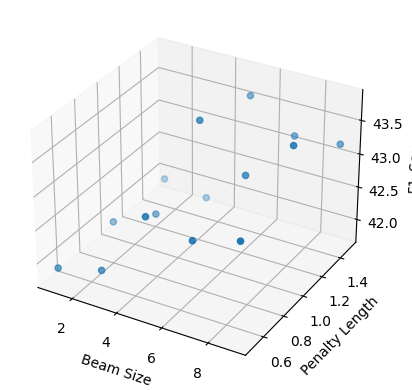

```python
import matplotlib.pyplot as plt
import numpy as np

fig = plt.figure()
ax = fig.add_subplot(projection='3d')
ax.scatter(beam_sizes, penalties, f1_scores)

ax.set_xlabel('Beam Size')
ax.set_ylabel('Penalty Length')
ax.set_zlabel('F1_Score')

plt.show()
```

```python
GOOD_HYPER_PARAMETERS = {
    "beam_size": 9,
    "length_penalty": 1.0,
}
```